# xU3LP Executive Summary

Spreek

5/10/2021

TL;DR

**DAI-USDC**: (0.9994, 1.0014)

**USDT-USDC**: (0.999, 1.001)

**sUSD-USDC**: (0.9974, 1.0054)*

**sETH-ETH**: (0.999, 1.001)*

**sBTC-WBTC**: (0.997, 1.005)*

**UST-USDT**: (0.9974, 1.0034)*

**FRAX-USDC**: (0.9944, 1.0044)*

**renBTC-WBTC**: (0.997, 1.000)

Pairs with a * next to their range should be reevaluated at current market price at time of LP program inception.

## Introduction

First, a few words about the approach I chose. The xU3LP tokens are intended to provide passive and consistent fee income from providing stablecoin liquidity in as efficient a manner as possible.

So we want to keep necessary rebalances to a minimum, and we don’t necessarily want to excessively speculate on stablecoin pegs. Of course, we will have to make some opinionated guesses about prices, and as we will see that biasing our liquidity towards 1 will give us better results.

Something important to understand is that uniswap liquidity *heavily* rewards concentrating your liquidity, so it is natural to feel like the recommended ranges are too narrow. Where possible I have aimed for consistency over higher averages, but you may still feel uncomfortable with it.

## Model

Our goal will be to optimize the fee share which I define as the $\frac{\text{Volume While Inside Range (a, b) * Amplification Factor(a,b)}}{\text{All Volume}}$ . You can think of it as roughly how much additional fees you would earn LPing in range (a,b) in a pool where everyone else provided Uniswap v2 style liquidity across from 0 to infinity. The amplification factor is $\frac{1}{(1-({\frac{b}{a}})^{0.25})}$ and reflects how many times more concentrated your liquidity is compared to a uniswap v2 LP.

We will set our range informed by historical data in two stages. Step 1 is to select a Center (broadly speaking, some combination of where price is and where we expect it to go) and then Step 2 is to select a spread (i.e. how wide the range should be).

I opted for a two parameter model, where the spread S is one parameter, and the center is determined as:

$\text{Center} = \lambda + (1-\lambda) * \text{current market price}$

In other words, $\lambda$ determines how much we shrink the market price closer to the peg. If $\lambda = 0$ then we use only the current price. If $\lambda = 1$ then we set the center at 1 regardless of the current market price. If $\lambda = 0.5$ we set the center at the midpoint between 1 and the current market price. The current market price can be taken as either the last close or some sort of short term TWAP or VWAP. Because of limitations of the curve API, I used the close price.

Once we have a spread S, and a center P, we will select the tick range closest to $(P-\frac{S}{2}, P + \frac{S}{2})$

Note: for some pairs, with low volatility where the strategy space is mostly constrained by tick ranges, I sometimes decided instead to just compare a few fixed tick ranges (rather than using lambda / S), as the more general strategy would have to be modified to find the nearest tick range anyway.

## Fitting parameters

In order to compare different combinations of $(S, \lambda)$, historical price data from Curve.fi API was used. To avoid overfitting, the following cross validation procedure was used:

Given ($\lambda$, S) and a starting date D, first, calculate the center P. Next, using historical price and volume data, we calculate fee share of the range $(P - \frac{S}{2}, P + \frac{S}{2})$ over the next N days.

Then we compare results looking ahead N days from all possible starting dates. We would like to see both a good average performance and reasonably consistent results.

## Limitations

I didn’t directly consider impermanent loss for a few reasons: 1) for stablecoin pairs with our assumptions, it should be quite minimal compared to fees and 2) it isn’t possible to directly compare the tradeoff between IL risk and fee returns without a good estimate of how large fee returns will be. At time of writing, before uniswap v3 is even released, estimating this even to an order of magnitude is extremely difficult.

The other major limitation is that the objective variable here does not take into account the dynamic nature of the uniswap v3 market. Clearly, other participants will structure their liquidity in such a way as to maximize their own returns as well, and this is likely to cause some changes to market structure as well as to expected returns.

I did try to make recommendations that are aware of these limitations and tried to err on the side of being safe with respect to them. After there is more uniswap v3 data, these questions should be revisited.

## Results

### DAI-USDC

Data from the curve 3pool after the introduction of the Dai Peg Stability Module (December 2020) was used. There was a clear breakpoint in the data at that point, and my belief is that data after December 2020 will be more predictive going forward. Due to the limited data, a 15 day lookahead period was used; however the recommendation was not sensitive to this choice.

**Recommended range: (0.9994, 1.0014)**

Backtesting verifies that the optimal strategy will involve a tight range near to 1. Given constraints of the tick ranges, we can choose between 4 primary strategies:

**Strategy A = (0.9994, 1.0004)**

**Strategy B = (1.0004, 1.0014)**

**Strategy C = (0.9994, 1.0014)**

**Strategy D = (0.9984, 1.0014)**

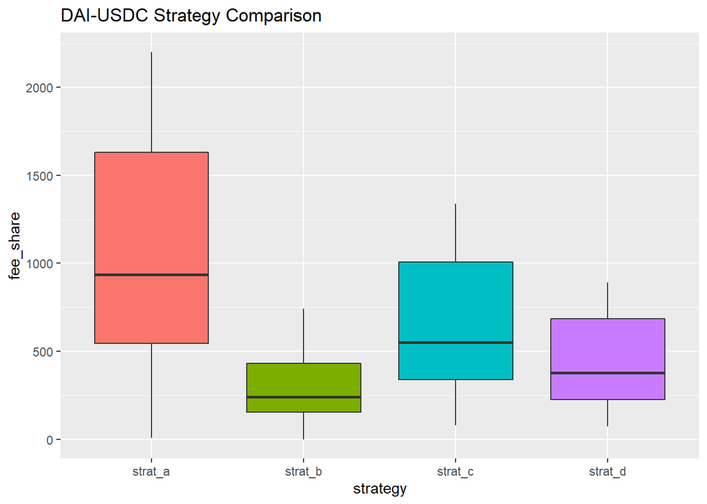

We see that the narrower ranges are hit or miss, and while strategy A has performed well recently, it is significantly less robust than a slightly wider range like strategy C. Strategy C also passes a sanity check on the overall volume profile a bit better. For those reasons, we will go with Strategy C.

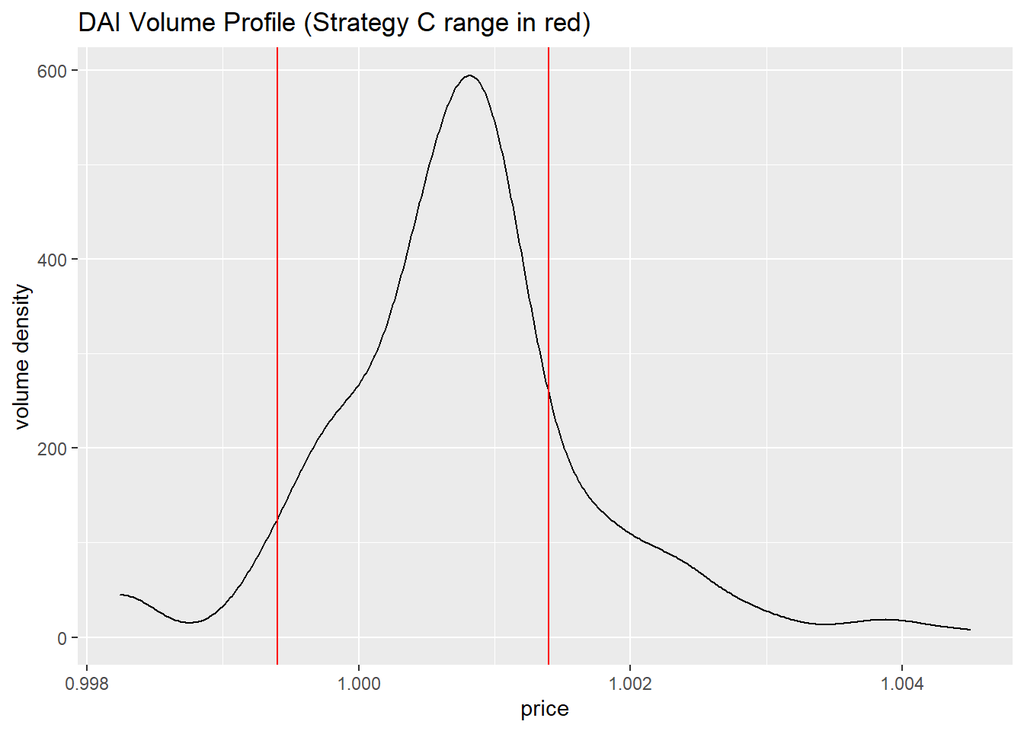

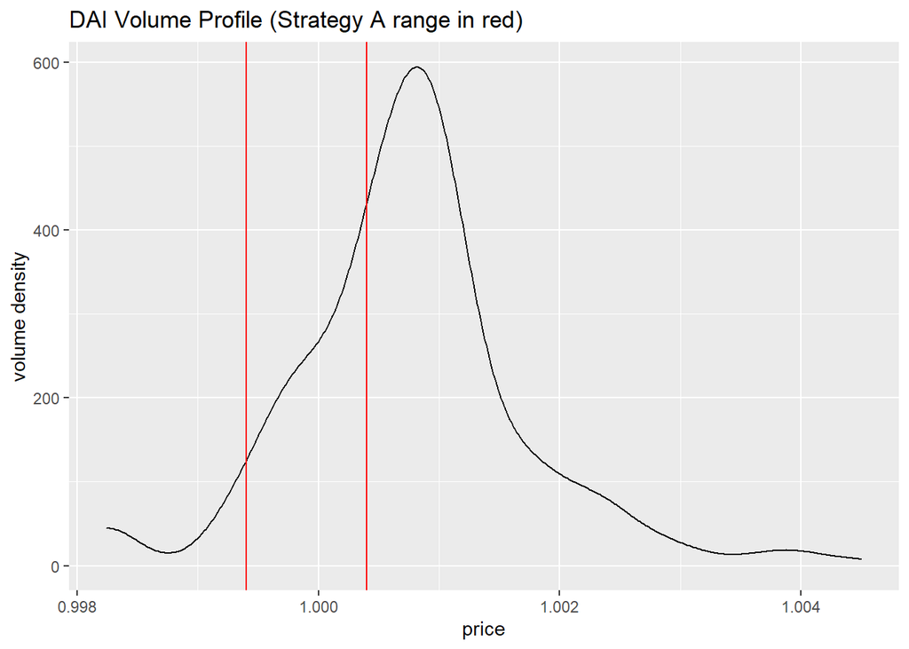

### USDT-USDC

Data from the curve 3pool was used with a lookahead of 30 days.

**Recommended range: (0.999,1.001)**

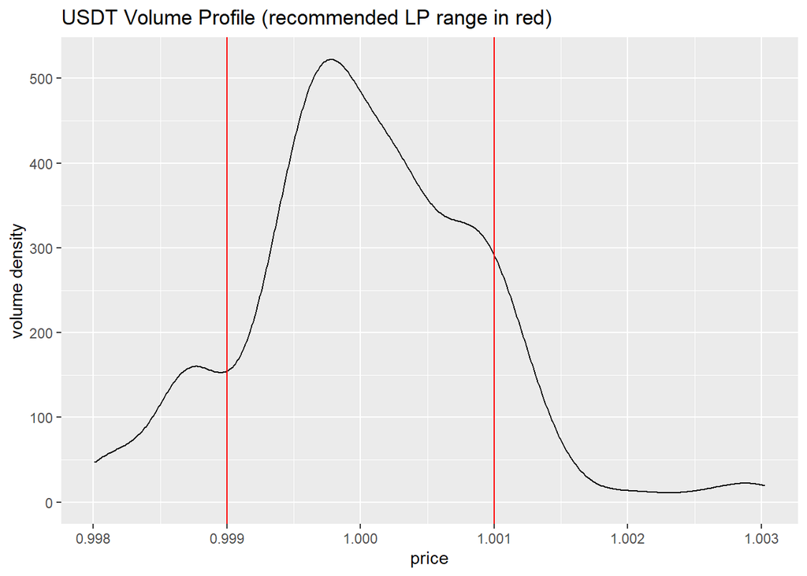

We see a similar shaped volume profile heavily concentrated around 1. Preliminary backtests confirmed that a concentrated tick range will be best. So next we compared the two major choices:

**Strategy A: (0.999, 1)**

**Strategy B: (0.999, 1.001)**

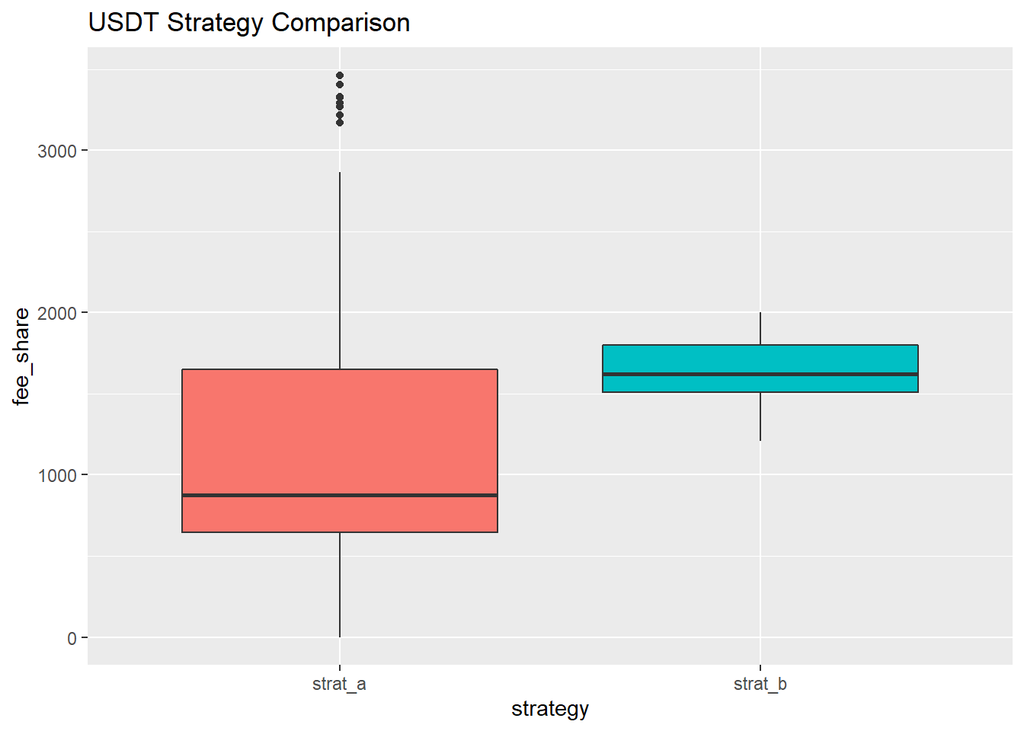

This time, we see a pretty clear outperformance from Strategy B, the wider range on both sides of 1, so we will go with that one.

### sUSD-USDC / sETH-ETH / sBTC-BTC

**Update: 10 May 2021**

With the imminent release of SIP 112 and the ETH wrappr, I have made the following revision.

**0.999-1.001 sETH-ETH**

**0.9974-1.0054 sUSD-USDC**

**0.997-1.005 sBTC-wBTC**

Idea is we basically want to maintain old ranges but cut off most of the arbable zone. After discussions with spartan council, the intended long term mint and burn fees on the wrapper will be 5-10 bps. Assume to be conservative that it will be 10 bps once it settles.

You can buy 1 sETH for 1.001 ETH by wrapping, as long as the wrapper is below its cap. You can redeem 1 sETH for 0.999 ETH, as long as the wrapper has ETH. So a range of 0.999-1.001 makes sense, as the non wrapper volume should tend to be overwhelmingly concentrated within that range.

It’s definitely hard to predict how this will play out, so this will still likely need further attention in the future when more data is available.

Previous analysis below conducted in April 2021 preserved for posterity

Data was collected from Curve API and backtests used a look ahead of 60 days. I used a longer look ahead here because sUSD curve pool is one of the oldest. Also, the synth time series is a bit less stationary than the other pairs examined here and I wanted to make sure that any strategy chosen was less likely to become obsolete quickly. Due to higher volatility of this pair, we need to use our general model to choose a strategy.

**Lambda = 0.65, S = 0.014**

**Range at time of writing: (0.997, 1.011)**

The synth pairs are significantly more volatile than the pairs examined above. This means that a wider spread is likely called for. Very small ranges still tended to have the highest *mean* fee share but they had substantially higher risk of earning very little or nothing at all. In practice, this would also manifest in higher impermanent loss.

While there are some differences in the volume distribution of the 3 different pairs here, they were not different enough to where I wanted to choose 3 different frameworks for the 3 different tokens. It would likely be fine to select the same range for all 3 pairs, although using the parameters and choosing 3 different but similar ranges also works.

I did a grid search across values of lambda and S, which did not ultimately find a conclusive best choice. I will present three different well performing strategies below and explain why I chose the one I did.

**Strategy A: $\lambda = 0.65, S = 0.002$**

**Strategy B: $\lambda = 0.65, S = 0.008$**

**Strategy C: $\lambda = 0.65, S = 0.014$**

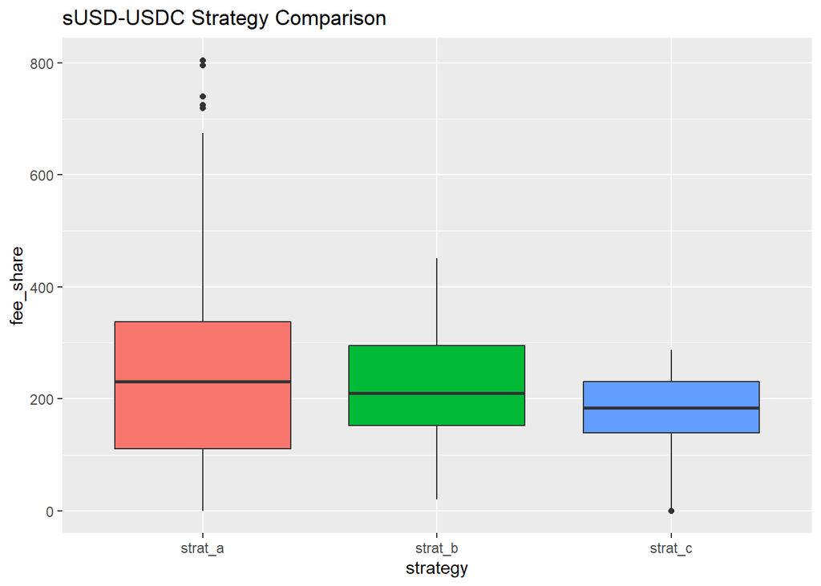

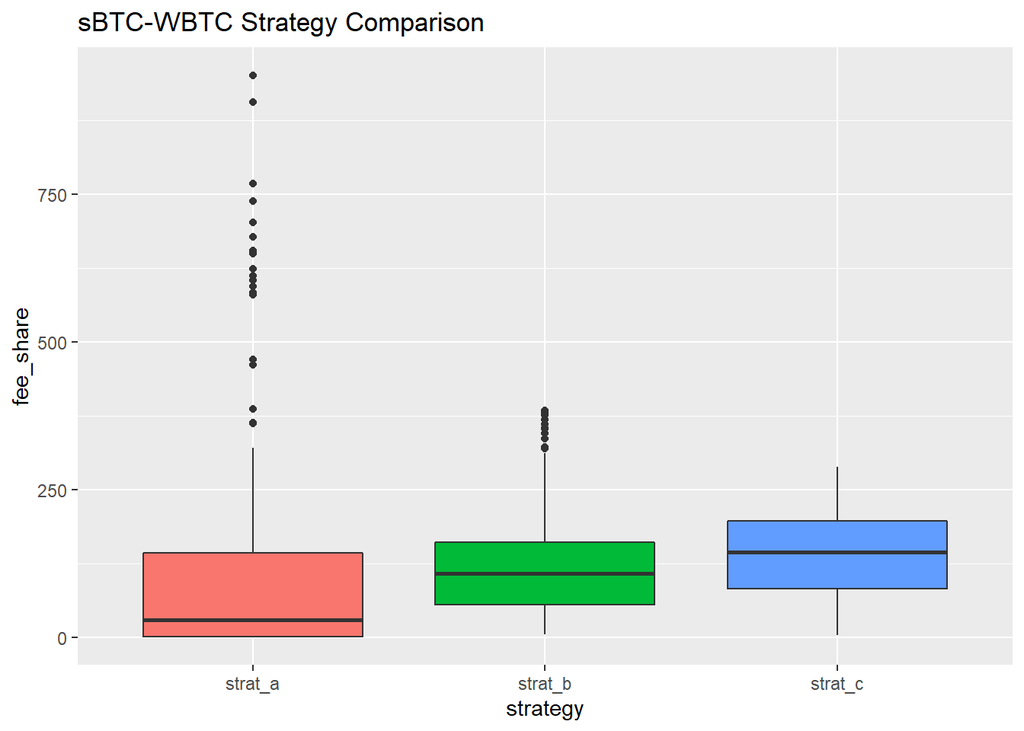

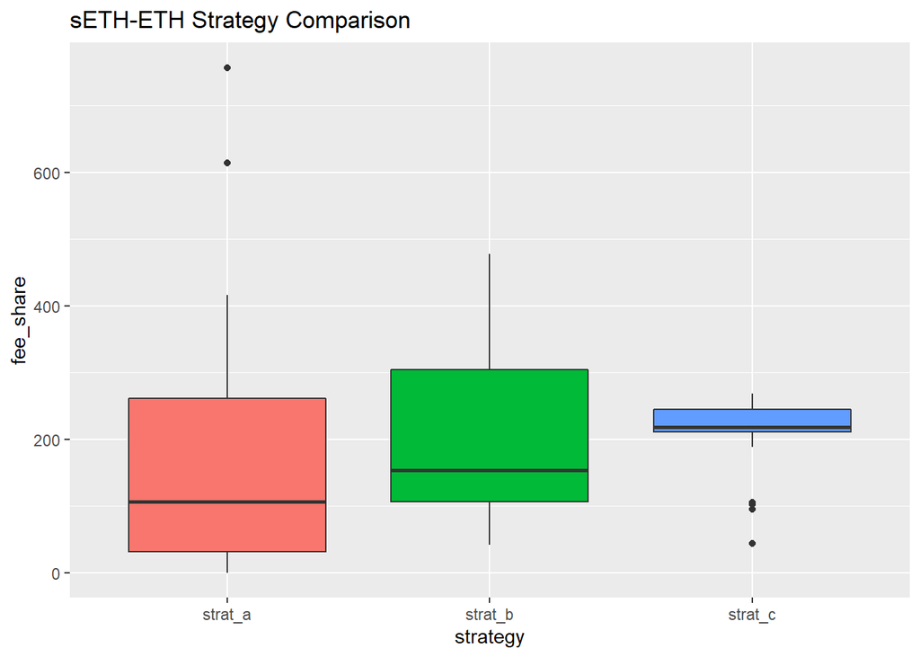

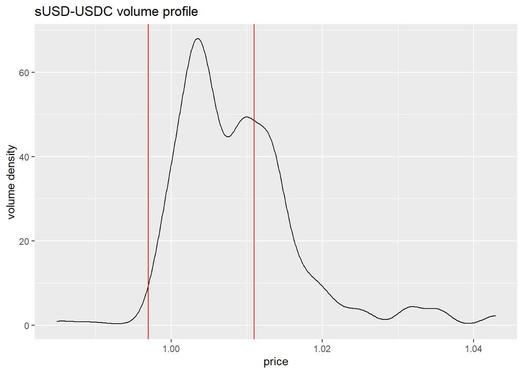

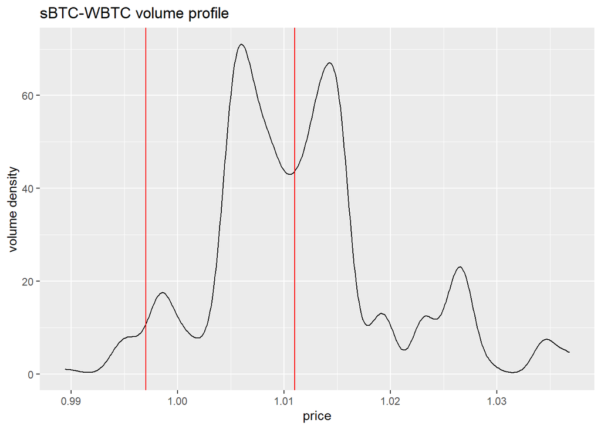

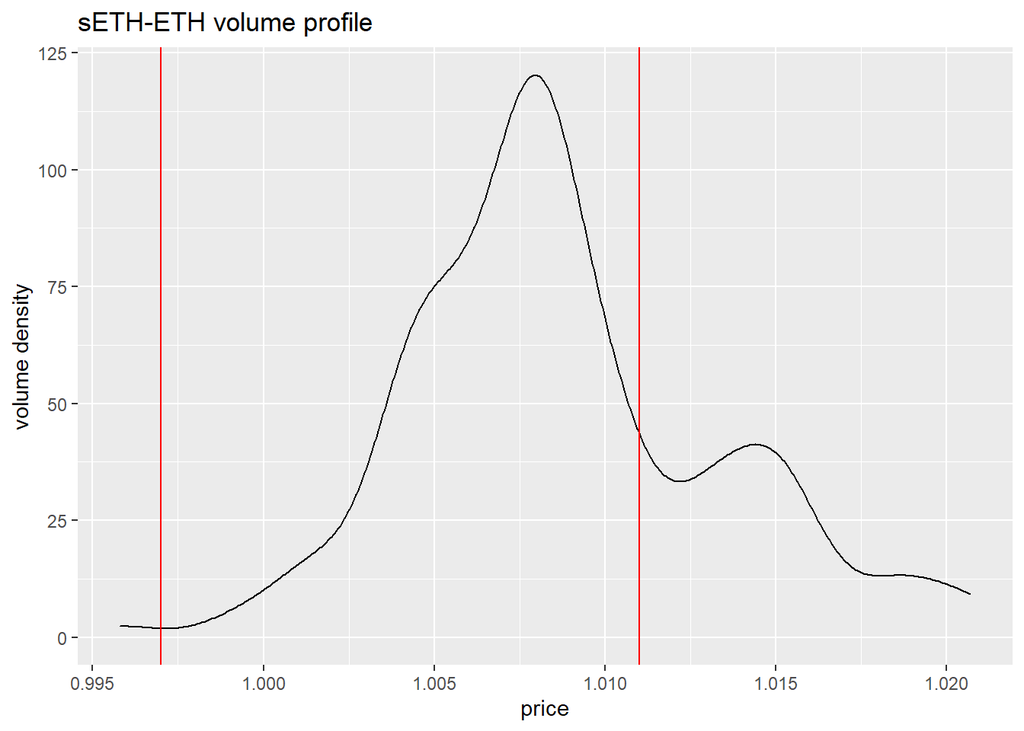

I also want to note that [SIP-112](https://sips.synthetix.io/sips/sip-112) has been approved and is currently in the process of being implemented. This is similar to the Peg Stability Module that successfully brought DAI to near peg for several months now. So depending on when this gets implemented and what changes in synth price action is observed, we may see a new regime closer to DAI-USDC today than to Synth volatility in the past.

With that in mind, it seems likely that these will have to be rebalanced at some point anyway. So picking something relatively unlikely to be a disaster was a priority over picking the most optimized for highest expected return that would have a 10% chance of earning nothing. It also means that biasing our liquidity towards 1-1 peg and accounting for the possibility of trading at a discount makes sense in the meantime.

### UST-USDT

We have pretty limited data from the Curve pool, so I used a look ahead of 15 days. It’s also important to keep in mind we have a limited sample for drawing conclusions about how stable or unstable it is. Largely, it appears there was one episode in Februrary of going substantially off peg for a few days – but the rest of the time it has been quite close to 1. Again, due to volatility we will primarily look at the general model.

**Lambda = 0.75, S = 0.006**

**Range at time of writing: (0.9974, 1.0034)**

We will look at 3 different strategies:

**Strategy A:** (0.999, 1.000) no matter what

**Strategy B:** $\lambda = 0.5, S = 0.002$

**Strategy C:** $\lambda = 0.75, S = 0.006$

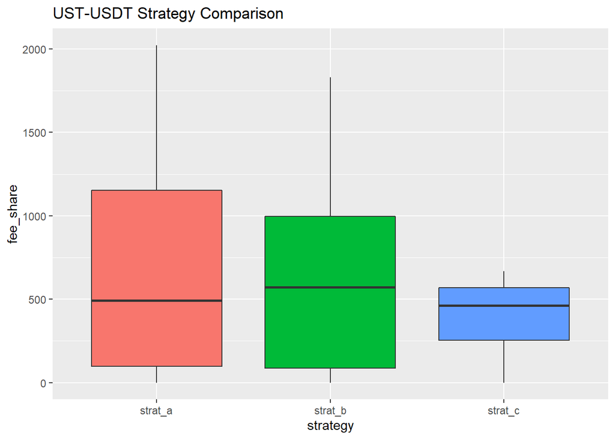

In this case, given the substantial uncertainty and small dataset, I will opt for the more conservative option C. It’s clear that UST has at least the possibility of being volatile occasionally, and it’s unclear how often or how extreme such volatility will happen.

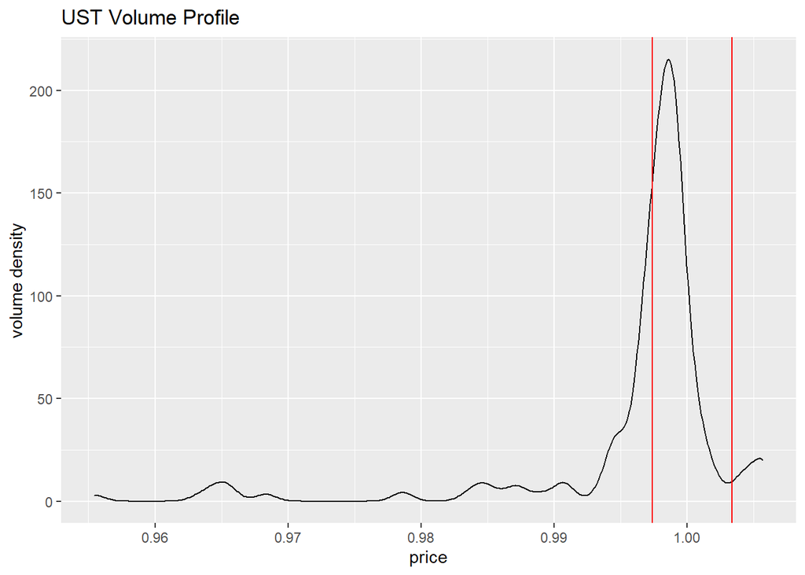

If UST continues to stay very on peg, then the S parameter could be shrunk at a later date, but I think it is wise to keep a bit wider range for the time being.

### FRAX-USDC

**Lambda = 0.5, S = 0.01**

**Range at time of writing: (0.9944, 1.0044)**

We also have very limited data here. It certainly appears that FRAX has been steadily dropping in volatility, especially after the introduction of the curve pool, however I still chose to look at the pre-curve data. Due to volatility still being high, we use the general model.

**Strategy 1: $\lambda = 0.5, S = 0.002$**

**Strategy 2: $\lambda = 0.5, S = 0.006$**

**Strategy 3: $\lambda = 0.5, S = 0.01$**

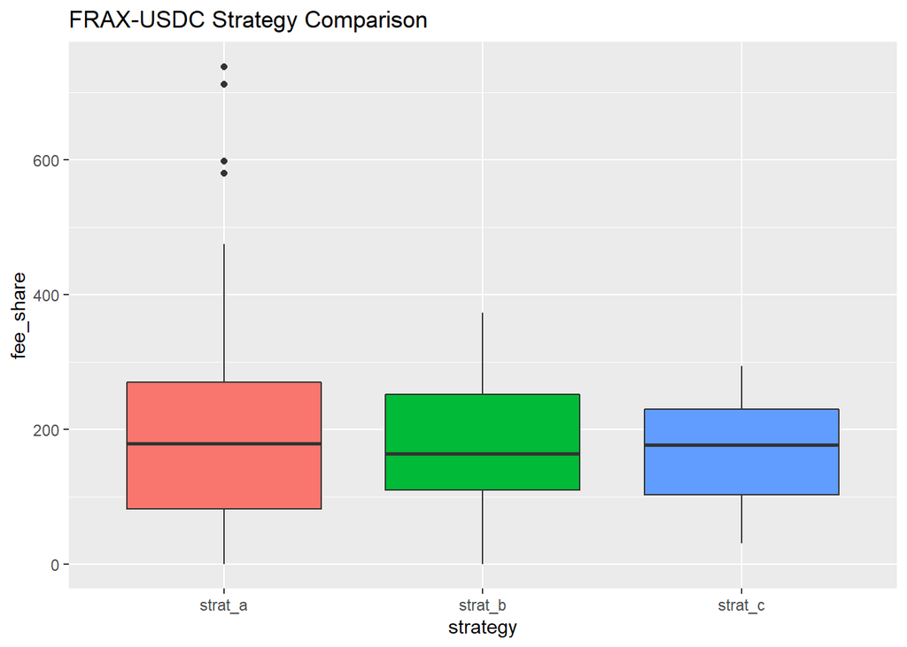

Given that the smaller spreads don’t seem to noticeably outperform and the uncertainty from a very small dataset, we will choose a larger spread for the time being.

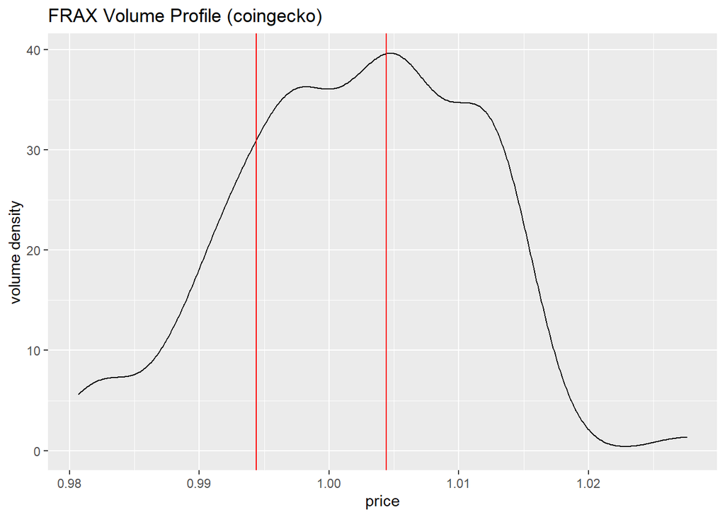

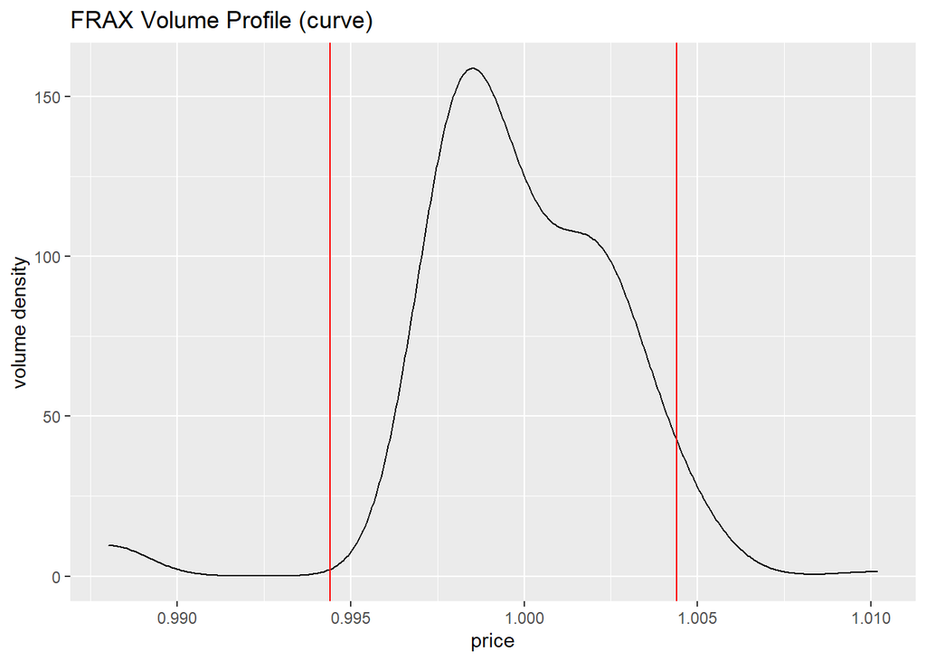

Judging by the curve volume profile, I suspect that this range can be narrowed in the future, but I would rather start too wide than too narrow.

### renBTC-WBTC

We use data from the renBTC-WBTC pair in the sbtc curve pool (which is still highly liquid for this pair - and has a much longer history than the renbtc pool) with a lookahead of 60 days. Due to low volatility, we will explore fixed tick ranges.

**Recommended Range at time of writing: (0.997, 1)**

Backtests confirmed that a small range is best for this pair, so we wanted to compare a number of fixed tick ranges.

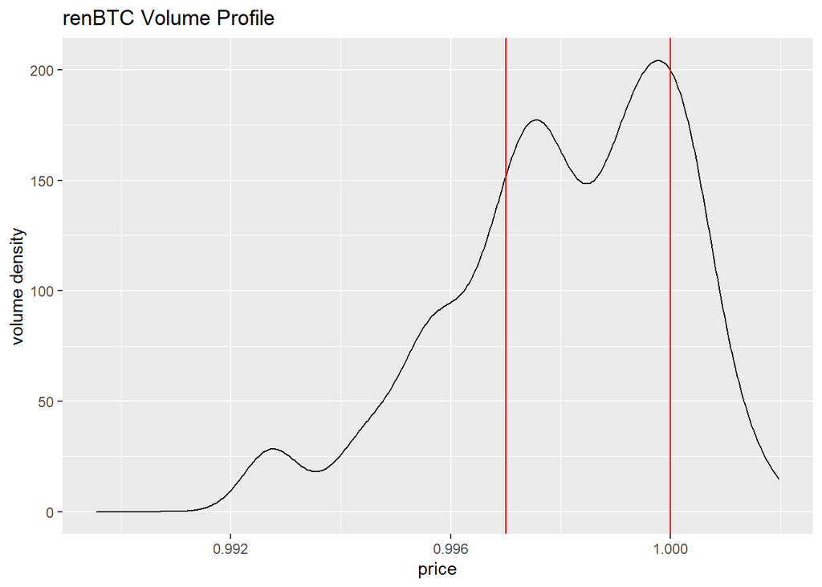

It’s important to recognize the fundamental flows at play here. renBTC is comparatively easy for many people to enter/exit from, while WBTC only allows a select few to enter/exit but is accepted/used in far more defi protocols. So as long as BTC is on net flowing into ETH on the retail side, we should expect renBTC to trade at a small discount to WBTC (such that no arb is possible).

If this changes, it would not be very expensive to rebalance to a range that goes above 1. So I considered 4 ranges below 1-1.

**Strategy A: (0.999, 1.000)**

**Strategy B: (0.998, 1.000)**

**Strategy C: (0.997, 1.000)**

**Strategy D: (0.996, 1.000)**

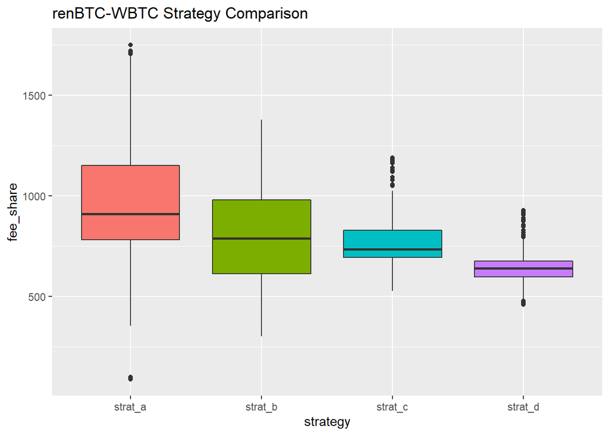

In this case, we will choose strategy c due to its lower risk while having solid average performance. Strategy D sees a large fall off (probably because once renBTC gets below 0.997 it starts to become arbable in many cases).

## Conclusions

For high volatility pairs (say, with a standard deviation of price greater than 0.005 or so), it makes sense to use a general model. A quick and dirty one would be $\lambda = 0.5$ and $S = 1.5*SDev(price)$. For lower volatility pairs, it is probably better to explore the space of tick ranges and choose the most robust one (keeping in mind fundamental factors that may cause the distribution to change over time).

Future work once more data is available should also consider the tradeoff between risks of IL and fee collection, game theory aspects of competing with other liquidity providers, and changes to stablecoin peg dynamics as the result of governance.